# INM430 - Tiny DS Project

**Student Name:** *Judith Grieves*

**Date:** *December 2019*

**Project Title:** *English Indices of Deprivation*

```python
%matplotlib inline

#import csv as csv
import numpy as np
import pandas as pd
import matplotlib.pyplot as plt

import geopandas as gpd
import altair as alt

# run the command below if using Altair in Jupyter Notebook
alt.renderers.enable('notebook')
```

```
RendererRegistry.enable('notebook')
```

## 1 Data Process

### 1.1 Data Load

Load each of the required datasets from Excel spreadsheets,CSV and files.  
The original data headings are informative but too long - they will be specified to more concise.

```python
######################################################
# import the Domains of Deprivation dataset
######################################################
# set up file reading parameters
Pdataset='File_2_-_IoD2019_Domains_of_Deprivation.xlsx'
Psheet_name="IoD2019 Domains"
Pheader=0
Pskiprows=0
Pusecols='A:T'
Pnames=['LSOAcode','LSOAname','LADcode','LADname','IMDRank','IMDDec','IncRank' #column names
       ,'IncDec','EmpRank','EmpDec','EduRank','EduDec'
                     ,'HealthRank','HealthDec','CrimeRank','CrimeDec','HouseRank','HouseDec','EnvRank','EnvDec']

Deprv = pd.read_excel(Pdataset,sheet_name=Psheet_name,header=Pheader
                      ,names=Pnames,skiprows=Pskiprows,usecols=Pusecols)

print('Deprivation: total rows raw data: ',Deprv.shape[0]) # number of data rows
```

```
Deprivation: total rows raw data:  32844
```

```python
######################################################
# import the Population Domains dataset
######################################################

# set up file reading parameters
Pdataset="File_6_-_IoD2019_Population_Denominators.xlsx"
Psheet_name="Population Denominators"
Pheader=0
Pskiprows=0
Pusecols='A:I'

Pnames=['LSOAcode','LSOAname','LADcode','LADname','TotalPop','DepChildnPop','16_59Pop'
       ,'OlderPop','WorkingPop']

Popn = pd.read_excel(Pdataset,sheet_name=Psheet_name,header=Pheader
                      ,names=Pnames,skiprows=Pskiprows,usecols=Pusecols)

print('\nPopulation: total rows raw data: ',Popn.shape[0]) # number of data rows
```

```
Population: total rows raw data:  32844
```

```python
######################################################
# import the Ward dataset
######################################################
# set up file reading parameters
Pdataset='Ward_to_Local_Authority_District.csv'
Pheader=0 # seems to ignore blank rows
Pusecols='A:L'
# give more meaningful column names than those supplied
Pnames=['WardCode','WardName','welsh','LADcode','LADname','LAcode','LAname','RegionCode','RegionName','CountryCode','CountryName']

Ward = pd.read_csv(Pdataset,header=0,names=Pnames,index_col=False)

print('\nWards: total rows raw data: ',Ward.shape[0]) # number of data rows
```

```
Wards: total rows raw data:  9114
```

```python
######################################################
# import the map dataset
######################################################
gb = gpd.read_file("shapefiles/boundaries_gb.shp")
gb.crs = {'init': 'epsg:27700'}
gb.loc[gb["geo_code"]=="E41000052",'geo_code'] = "E06000052" # update Cornwall
gb.loc[gb["geo_code"]=="E41000324",'geo_code'] = "E09000033" # update Westminster
gb.loc[gb["geo_code"]=="E06000048",'geo_code'] = "E06000057" # update Northumberland to Deprv value
gb.loc[gb["geo_code"]=="E07000100",'geo_code'] = "E07000240" # update St Albans to Deprv value
gb.loc[gb["geo_code"]=="E07000101",'geo_code'] = "E07000243" # update Stevenage to Deprv value
gb.loc[gb["geo_code"]=="E07000104",'geo_code'] = "E07000241" # update Welwyn/Hatfields to Deprv value

print('\nMap shapefile: total rows raw data: ',gb.shape[0]) # number of data rows
```

```
Map shapefile: total rows raw data:  378
```

### 1.2 Data Load Validation

Check for NULL values in data - none found except some data in Wards that will not be used.

```python
# Confirm that column headers and summary statistics are as expected

print('\n',Deprv.columns)   # validate that headers applied correctly
print(Deprv.describe()) # check for any null data columns - none found


print('\n',Popn.columns)   # validate that headers are as expected
print(Popn.describe()) #check for any null data columns - none found

print('\n',Ward.columns) # check the column names
print(Ward.describe()) # check for any null data columns - none found
```

```
 Index(['LSOAcode', 'LSOAname', 'LADcode', 'LADname', 'IMDRank', 'IMDDec',
       'IncRank', 'IncDec', 'EmpRank', 'EmpDec', 'EduRank', 'EduDec',
       'HealthRank', 'HealthDec', 'CrimeRank', 'CrimeDec', 'HouseRank',
       'HouseDec', 'EnvRank', 'EnvDec'],
      dtype='object')
            IMDRank        IMDDec       IncRank        IncDec       EmpRank  \
count  32844.000000  32844.000000  32844.000000  32844.000000  32844.000000
mean   16422.499208      5.500122  16422.498478      5.500122  16422.498295
std     9481.390454      2.872325   9481.389874      2.872325   9481.390049
min        1.000000      1.000000      1.000000      1.000000      1.000000
25%     8211.750000      3.000000   8211.750000      3.000000   8211.750000
50%    16422.500000      5.500000  16422.500000      5.500000  16422.500000
75%    24633.250000      8.000000  24633.250000      8.000000  24633.250000
max    32844.000000     10.000000  32844.000000     10.000000  32844.000000

             EmpDec       EduRank        EduDec    HealthRank     HealthDec  \
count  32844.000000  32844.000000  32844.000000  32844.000000  32844.000000
mean       5.500122  16422.499391      5.500122  16422.499604      5.500122
std        2.872325   9481.390506      2.872325   9481.390480      2.872325
min        1.000000      1.000000      1.000000      1.000000      1.000000
25%        3.000000   8211.750000      3.000000   8211.750000      3.000000
50%        5.500000  16422.500000      5.500000  16422.500000      5.500000
75%        8.000000  24633.250000      8.000000  24633.250000      8.000000
max       10.000000  32844.000000     10.000000  32844.000000     10.000000

          CrimeRank      CrimeDec     HouseRank      HouseDec       EnvRank  \
count  32844.000000  32844.000000  32844.000000  32844.000000  32844.000000
mean   16422.499878      5.500122  16422.499361      5.500122  16422.499543
std     9481.390342      2.872325   9481.390512      2.872325   9481.390649
min        1.000000      1.000000      1.000000      1.000000      1.000000
25%     8211.750000      3.000000   8211.750000      3.000000   8211.750000
50%    16422.500000      5.500000  16422.500000      5.500000  16422.500000
75%    24633.250000      8.000000  24633.250000      8.000000  24633.250000
max    32844.000000     10.000000  32844.000000     10.000000  32844.000000

             EnvDec
count  32844.000000
mean       5.500122
std        2.872325
min        1.000000
```

[output cut: 17 more lines]

```

 Index(['WardCode', 'WardName', 'welsh', 'LADcode', 'LADname', 'LAcode',
       'LAname', 'RegionCode', 'RegionName', 'CountryCode', 'CountryName'],
      dtype='object')
         WardCode WardName          welsh    LADcode   LADname     LAcode  \
count        9114     9114            852       9114      9114       5833
unique       9114     8386            831        391       391         35
top     E05007848   Castle  Llansanffraid  E06000052  Cornwall  E13000002
freq            1       26              3        122       122        382

              LAname RegionCode  RegionName CountryCode CountryName
count           5833       7446        7446        9114        9114
unique            35          9           9           4           4
top     Outer London  E12000008  South East   E92000001     England
freq             382       1397        1397        7446        7446
```

### 1.3 Data Transformation

1.3.1. Amend some of the geo codes that are mismatched between Deprivation/Popn and Ward/map data.  
The geographical areas are subject to change and these datasets are from different time periods.

```python
# update changed LAD codes
Deprv.loc[Deprv["LADcode"]=="E07000244",'LADcode']  = "E07000205" # update to Suffolk Coastal
Deprv.loc[Deprv["LADname"]=="East Suffolk",'LADname']  = "Suffolk Coastal" # update to Suffolk Coastal
Deprv.loc[Deprv["LADcode"]=="E07000245",'LADcode']  = "E07000205" # update to Suffolk Coastal
Deprv.loc[Deprv["LADname"]=="West Suffolk",'LADname']  = "Suffolk Coastal" # update to Suffolk Coastal

Popn.loc[Popn["LADcode"]=="E07000244",'LADcode']  = "E07000205" # update to Suffolk Coastal
Popn.loc[Popn["LADname"]=="East Suffolk",'LADname']  = "Suffolk Coastal" # update to Suffolk Coastal
Popn.loc[Popn["LADcode"]=="E07000245",'LADcode']  = "E07000205" # update to Suffolk Coastal
Popn.loc[Popn["LADname"]=="West Suffolk",'LADname']  = "Suffolk Coastal" # update to Suffolk Coastal
```

```python
# a function to update LSOA LAD codes and names based on LSOA names so that Deprv matches Wards and Maps

def LADfix(search,LADname,LADcode):
    #update the Popn/Deprv datasets with LADs to match Ward/map files
    Popn.loc[Popn["LSOAname"].str.contains(pat=search),'LADname']  = LADname
    Popn.loc[Popn["LSOAname"].str.contains(pat=search),'LADcode']  = LADcode
    Deprv.loc[Deprv["LSOAname"].str.contains(pat=search),'LADname']  = LADname
    Deprv.loc[Deprv["LSOAname"].str.contains(pat=search),'LADcode']  = LADcode

#set LAD code/name to correct values
LADfix("Taunton Deane","Taunton Deane","E07000190")
LADfix("West Somerset","West Somerset","E07000191")
LADfix("Poole","Poole","E06000029")
LADfix("Bournemouth","Bournemouth","E06000028")
LADfix("Christchurch","Christchurch","E07000048")
LADfix("North Dorset","North Dorset","E07000050")
LADfix("West Dorset","West Dorset","E07000052")
LADfix("East Dorset","East Dorset","E07000049")
LADfix("Purbeck","Purbeck","E07000051")
LADfix("Weymouth and Portland","Weymouth and Portland","E07000053")

Popn[Popn["LSOAname"].str.contains(pat="Purbeck")].groupby(["LADcode","LADname"]).count()
```

| LADcode | LADname | LSOAcode | LSOAname | TotalPop | DepChildnPop | 16_59Pop | OlderPop | WorkingPop |
| --- | --- | --- | --- | --- | --- | --- | --- | --- |
| E07000051 | Purbeck | 29 | 29 | 29 | 29 | 29 | 29 | 29 |

1.3.2. Create new columns in the Population dataset to show the percentage of population of age subsets - these %s may be correlated to the Deprivation of an area or be predictors of Health deprivation

```python
Popn['DepChildnPerc']=Popn['DepChildnPop']/Popn['TotalPop']
Popn['OlderPerc']=Popn['OlderPop']/Popn['TotalPop']
Popn['16_59Perc']=Popn['16_59Pop']/Popn['TotalPop']
Popn['WorkingPerc']=Popn['WorkingPop']/Popn['TotalPop']
Popn.head()
```

|  | LSOAcode | LSOAname | LADcode | LADname | TotalPop | DepChildnPop | 16_59Pop | OlderPop | WorkingPop | DepChildnPerc | OlderPerc | 16_59Perc | WorkingPerc |
| --- | --- | --- | --- | --- | --- | --- | --- | --- | --- | --- | --- | --- | --- |
| 0 | E01000001 | City of London 001A | E09000001 | City of London | 1296 | 175 | 656 | 465 | 715.00 | 0.135031 | 0.358796 | 0.506173 | 0.551698 |
| 1 | E01000002 | City of London 001B | E09000001 | City of London | 1156 | 182 | 580 | 394 | 619.75 | 0.157439 | 0.340830 | 0.501730 | 0.536116 |
| 2 | E01000003 | City of London 001C | E09000001 | City of London | 1350 | 146 | 759 | 445 | 804.00 | 0.108148 | 0.329630 | 0.562222 | 0.595556 |
| 3 | E01000005 | City of London 001E | E09000001 | City of London | 1121 | 229 | 692 | 200 | 683.00 | 0.204282 | 0.178412 | 0.617306 | 0.609277 |
| 4 | E01000006 | Barking and Dagenham 016A | E09000002 | Barking and Dagenham | 2040 | 522 | 1297 | 221 | 1284.50 | 0.255882 | 0.108333 | 0.635784 | 0.629657 |

1.3.3. Group the Ward data to create a lookup of Region by LA district in order to join later to Deprivation so that it can be analysed by Region.

```python
by=['LADcode','LADistrict','RegionCode','RegionName','CountryCode','CountryName'] # exclude ,'LAcode','LAname'
LADistrict = Ward.loc[:,['LADcode','LADname','RegionCode','RegionName','CountryCode','CountryName']].drop_duplicates()
LADistrict.head()
```

|  | LADcode | LADname | RegionCode | RegionName | CountryCode | CountryName |
| --- | --- | --- | --- | --- | --- | --- |
| 0 | E06000013 | North Lincolnshire | E12000003 | Yorkshire and The Humber | E92000001 | England |
| 1 | E06000001 | Hartlepool | E12000001 | North East | E92000001 | England |
| 2 | E06000006 | Halton | E12000002 | North West | E92000001 | England |
| 3 | E06000010 | Kingston upon Hull, City of | E12000003 | Yorkshire and The Humber | E92000001 | England |
| 7 | E06000011 | East Riding of Yorkshire | E12000003 | Yorkshire and The Humber | E92000001 | England |

1.3.4. Merge the Ward, Deprivation and Population data at the LSOA level to create a master dataset

```python
PopDepLSOA = pd.merge(Deprv,Popn,left_on=['LSOAcode','LSOAname','LADcode','LADname'], right_on=['LSOAcode','LSOAname','LADcode','LADname'], how='left')
PopDepLSOA = pd.merge(PopDepLSOA,LADistrict,left_on=['LADcode','LADname'], right_on=['LADcode','LADname'], how='left')

PopDepLSOA.head()
```

|  | LSOAcode | LSOAname | LADcode | LADname | IMDRank | IMDDec | IncRank | IncDec | EmpRank | EmpDec | ... | OlderPop | WorkingPop | DepChildnPerc | OlderPerc | 16_59Perc | WorkingPerc | RegionCode | RegionName | CountryCode | CountryName |
| --- | --- | --- | --- | --- | --- | --- | --- | --- | --- | --- | --- | --- | --- | --- | --- | --- | --- | --- | --- | --- | --- |
| 0 | E01000001 | City of London 001A | E09000001 | City of London | 29199 | 9 | 32831 | 10 | 32742 | 10 | ... | 465 | 715.00 | 0.135031 | 0.358796 | 0.506173 | 0.551698 | E12000007 | London | E92000001 | England |
| 1 | E01000002 | City of London 001B | E09000001 | City of London | 30379 | 10 | 29901 | 10 | 31190 | 10 | ... | 394 | 619.75 | 0.157439 | 0.340830 | 0.501730 | 0.536116 | E12000007 | London | E92000001 | England |
| 2 | E01000003 | City of London 001C | E09000001 | City of London | 14915 | 5 | 18510 | 6 | 15103 | 5 | ... | 445 | 804.00 | 0.108148 | 0.329630 | 0.562222 | 0.595556 | E12000007 | London | E92000001 | England |
| 3 | E01000005 | City of London 001E | E09000001 | City of London | 8678 | 3 | 6029 | 2 | 7833 | 3 | ... | 200 | 683.00 | 0.204282 | 0.178412 | 0.617306 | 0.609277 | E12000007 | London | E92000001 | England |
| 4 | E01000006 | Barking and Dagenham 016A | E09000002 | Barking and Dagenham | 14486 | 5 | 14023 | 5 | 21692 | 7 | ... | 221 | 1284.50 | 0.255882 | 0.108333 | 0.635784 | 0.629657 | E12000007 | London | E92000001 | England |

5 rows × 33 columns

1.3.5. Update LAD codes which don't match those in maps

```python
# fix LADcode in PopDepLSOA before creating PopDepLAD and joining to maps
PopDepLSOA.loc[PopDepLSOA["LADcode"]=="E08000037",'LADcode']  = "E08000020" #Gateshead
PopDepLSOA.loc[PopDepLSOA["LADcode"]=="E07000242",'LADcode']  = "E07000097" #Hertfordshire

PopDepLSOA[PopDepLSOA["LADname"]=="East Hertfordshire"].head()
PopDepLSOA[PopDepLSOA["LADname"]=="Gateshead"].head()
```

|  | LSOAcode | LSOAname | LADcode | LADname | IMDRank | IMDDec | IncRank | IncDec | EmpRank | EmpDec | ... | OlderPop | WorkingPop | DepChildnPerc | OlderPerc | 16_59Perc | WorkingPerc | RegionCode | RegionName | CountryCode | CountryName |
| --- | --- | --- | --- | --- | --- | --- | --- | --- | --- | --- | --- | --- | --- | --- | --- | --- | --- | --- | --- | --- | --- |
| 7948 | E01008162 | Gateshead 027A | E08000020 | Gateshead | 11206 | 4 | 12600 | 4 | 13843 | 5 | ... | 303 | 2116.00 | 0.120843 | 0.111973 | 0.767184 | 0.781966 | E12000001 | North East | E92000001 | England |
| 7949 | E01008163 | Gateshead 028A | E08000020 | Gateshead | 6621 | 3 | 9233 | 3 | 6188 | 2 | ... | 323 | 1107.50 | 0.294173 | 0.151786 | 0.554041 | 0.520442 | E12000001 | North East | E92000001 | England |
| 7950 | E01008164 | Gateshead 027B | E08000020 | Gateshead | 2081 | 1 | 2240 | 1 | 2486 | 1 | ... | 236 | 1005.25 | 0.181939 | 0.156707 | 0.661355 | 0.667497 | E12000001 | North East | E92000001 | England |
| 7951 | E01008165 | Gateshead 011A | E08000020 | Gateshead | 1341 | 1 | 1477 | 1 | 1701 | 1 | ... | 249 | 885.50 | 0.205357 | 0.171016 | 0.623626 | 0.608173 | E12000001 | North East | E92000001 | England |
| 7952 | E01008166 | Gateshead 027C | E08000020 | Gateshead | 6148 | 2 | 7757 | 3 | 8396 | 3 | ... | 219 | 1355.75 | 0.021883 | 0.145225 | 0.832891 | 0.899038 | E12000001 | North East | E92000001 | England |

5 rows × 33 columns

1.3.6. group the main dataset to give results by LA district: use MEAN() for the ranks, deciles and population %s and use SUM() for Population totals.

Analysis of Population data below shows that values for an LSOA range from 523 to 9551 - Population should therefore be used in weighting the Deprivation averages.

```python
#  calculate weighted means for LAD

# calculate the total pop for an LAD
PopnLAD=PopDepLSOA[['LADcode','LADname','RegionName','TotalPop']].groupby(['LADcode','LADname','RegionName']).sum();
PopnLAD=PopnLAD.rename(columns = {'TotalPop':'LADPop'})

# create a copy of LSOA data and update the rank/deciles to weighted values before grouping by LAD
keycols=['LSOAcode', 'LSOAname', 'LADcode', 'LADname','RegionName']
rankcols = ['IMDRank', 'IMDDec',
       'IncRank', 'IncDec', 'EmpRank', 'EmpDec', 'EduRank', 'EduDec',
       'HealthRank', 'HealthDec', 'CrimeRank', 'CrimeDec', 'HouseRank',
       'HouseDec', 'EnvRank', 'EnvDec']
Popcols=['TotalPop', 'DepChildnPop', '16_59Pop',
       'OlderPop', 'WorkingPop', 'DepChildnPerc', 'OlderPerc', '16_59Perc',
       'WorkingPerc']
temp=pd.merge(PopDepLSOA,PopnLAD,how='inner',on=['LADcode','LADname','RegionName'])
temprank=temp[rankcols].apply(lambda x: x*temp['TotalPop']/temp['LADPop'], axis=0)
#
tempkey=temp[keycols]
tempPop=temp[Popcols]
temp=pd.concat([tempkey,temprank,tempPop],axis=1)
PopDepLAD=temp.groupby(['LADcode','LADname','RegionName']).sum() # new weighted PopDepLAD
PopDepLAD = PopDepLAD.reset_index(drop=False)
PopDepLAD.sort_values(by=['IMDDec','RegionName','LADname']).head(10)

PopDepLAD['CrimeRank'].mean()
```

```
18165.43138674471
```

1.3.7 Join the LA district data to the shape file in order to visualise as maps.

```python
PopDepMap = pd.merge(gb,PopDepLAD,left_on='geo_code', right_on='LADcode', how='left')
PopDepMap.geo_code.count()
```

```
378
```

```python
PopDepMap.loc[PopDepMap['LADcode'].isnull()].sort_values(by='geo_code').head(5) # 3 Enlish LADs not joined
```

|  | geo_labelw | geo_label | geo_code | AREA | PERIMETER | geometry | LADcode | LADname | RegionName | IMDRank | ... | EnvDec | TotalPop | DepChildnPop | 16_59Pop | OlderPop | WorkingPop | DepChildnPerc | OlderPerc | 16_59Perc | WorkingPerc |
| --- | --- | --- | --- | --- | --- | --- | --- | --- | --- | --- | --- | --- | --- | --- | --- | --- | --- | --- | --- | --- | --- |
| 129 | None | Forest Heath | E07000201 | 3.778438e+08 | 136277.868315 | POLYGON ((565236.803 284823.57, 573643 287289,... | NaN | NaN | NaN | NaN | ... | NaN | NaN | NaN | NaN | NaN | NaN | NaN | NaN | NaN | NaN |
| 290 | None | St Edmundsbury | E07000204 | 6.570390e+08 | 178702.915857 | POLYGON ((584651.6899999999 280859.5, 598909.6... | NaN | NaN | NaN | NaN | ... | NaN | NaN | NaN | NaN | NaN | NaN | NaN | NaN | NaN | NaN |
| 339 | None | Waveney | E07000206 | 3.696889e+08 | 130887.985082 | (POLYGON ((647472.497 276653.902, 647163.81499... | NaN | NaN | NaN | NaN | ... | NaN | NaN | NaN | NaN | NaN | NaN | NaN | NaN | NaN | NaN |
| 243 | None | Clackmannanshire | S12000005 | 1.589388e+08 | 77591.673205 | POLYGON ((282997.2999999998 694569.6999999993,... | NaN | NaN | NaN | NaN | ... | NaN | NaN | NaN | NaN | NaN | NaN | NaN | NaN | NaN | NaN |
| 29 | None | Dumfries & Galloway | S12000006 | 6.430582e+09 | 795332.954045 | POLYGON ((304665.5 614182.5999999996, 306785 6... | NaN | NaN | NaN | NaN | ... | NaN | NaN | NaN | NaN | NaN | NaN | NaN | NaN | NaN | NaN |

5 rows × 34 columns

```python
PopDepMap.IMDDec.mean()
```

```
5.869751404796758
```

1.3.8 the Geo / Deprivation datasets are stil out of line for 3 entries so do a LEFT join and default the null values to the mean value as a short term solution to fully visualise the maps.

```python
# code to populate the nulls in PopDepMap where there is no deprivation data (Scotland, Wales & some mismatched areas)
# default to the mean value

# Set missing values to a default of 10 (least deprived)
Ranklist=['IMDRank', 'IncRank',
       'EmpRank', 'EduRank','HealthRank', 'CrimeRank',  'HouseRank',   'EnvRank']

Declist=['IMDDec',    'IncDec', 'EmpDec', 'EduDec',  'HealthDec', 'CrimeDec',  'HouseDec',
       'EnvRank', 'EnvDec']
for colname in Ranklist:
    PopDepMap.loc[PopDepMap[colname].isnull(),colname] = PopDepMap[colname].mean()
for colname in Declist:
    PopDepMap.loc[PopDepMap[colname].isnull(),colname] = PopDepMap[colname].mean()

PopDepMap.IMDRank.mean()
PopDepMap.IMDDec.mean()
PopDepMap.loc[PopDepMap['IMDDec'].isnull()].head() # no more nulls
```

|  | geo_labelw | geo_label | geo_code | AREA | PERIMETER | geometry | LADcode | LADname | RegionName | IMDRank | ... | EnvDec | TotalPop | DepChildnPop | 16_59Pop | OlderPop | WorkingPop | DepChildnPerc | OlderPerc | 16_59Perc | WorkingPerc |
| --- | --- | --- | --- | --- | --- | --- | --- | --- | --- | --- | --- | --- | --- | --- | --- | --- | --- | --- | --- | --- | --- |

0 rows × 34 columns

```python
# new column to reverse the Deprivation decile rank - may be more easily understood in some cases

#  make most deprived the high number
PopDepMap = PopDepMap.assign(Deprivation_1_10 = 11-PopDepMap["IMDDec"])
PopDepMap.Deprivation_1_10.count()
```

```
378
```

```python
# check the counts of all base and derived datasets

print('Deprv', Deprv['LADcode'].nunique()) #323
print('Popn', Popn['LADcode'].nunique()) #323
print('Ward',Ward['LADcode'].nunique()) #391 wards that are not in Deprv data - OK
print('LADistrict',LADistrict['LADcode'].nunique()) #391

print('PopDepLSOA',PopDepLSOA['LADcode'].nunique()) #323
print('PopDepLAD',PopDepLAD['LADcode'].nunique()) # 323

print('PopDepMap',PopDepMap['LADcode'].count()) #321 - only 2 areas not matching to mapfile
print('gb geo_code',gb['geo_code'].count()) #317

print('Popn TotalPop sum',Popn[['TotalPop']].sum()) # total population 54728204
print('PopDepLSOA TotalPop sum',PopDepLSOA[['TotalPop']].sum()) # total joined population 54728204
print('PopDepLAD TotalPop sum',PopDepLAD[['TotalPop']].sum()) # total joined population 54728204
print('PopDepMap TotalPop sum',PopDepMap[['TotalPop']].sum()) # total joined population 54719182!!!!

print("null regions:\n",PopDepLSOA[PopDepLSOA.RegionName.isnull()].groupby('LADname').count()) # show any null regions

print('PopDepLSOA IMDDec',PopDepLSOA[['IMDDec']].sum().sum()) # 180646
```

```
Deprv 323
Popn 323
Ward 391
LADistrict 391
PopDepLSOA 323
PopDepLAD 323
PopDepMap 321
gb geo_code 378
Popn TotalPop sum TotalPop    54728204
dtype: int64
PopDepLSOA TotalPop sum TotalPop    54728204
dtype: int64
PopDepLAD TotalPop sum TotalPop    54728204
dtype: int64
PopDepMap TotalPop sum TotalPop    54719182.0
dtype: float64
null regions:
 Empty DataFrame
Columns: [LSOAcode, LSOAname, LADcode, IMDRank, IMDDec, IncRank, IncDec, EmpRank, EmpDec, EduRank, EduDec, HealthRank, HealthDec, CrimeRank, CrimeDec, HouseRank, HouseDec, EnvRank, EnvDec, TotalPop, DepChildnPop, 16_59Pop, OlderPop, WorkingPop, DepChildnPerc, OlderPerc, 16_59Perc, WorkingPerc, Regio…
Index: []

[0 rows x 32 columns]
PopDepLSOA IMDDec 180646
```

## 2 Exploratory Data Analysis

Do some exploratory data analysis to provide overall context and look for trends and anomalies. Use deciles here to give a concise 1-10 view of Deprivation.

### 2.1 Deprivation by Region

The bar chart shows the Regions in order of mean deprivation and box plots show the differences in the median and spread of the Index of Multiple Deprivation Rank for each Region. The boxplots showed that the ordering by median is different to that by Mean so we add a barchart ordering by Median.

Note that Mean and Median show different results because of the the difference in range and distribution of Deprivation.

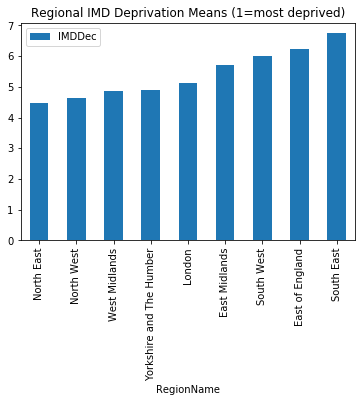

```python
Region = PopDepLSOA.groupby('RegionName').mean()

# plot the overall Deprivation index by Region to see the picture for all of England
ax1 = Region[['IMDDec']].sort_values(by ='IMDDec',ascending=True).plot.bar( rot=90)
ax1.set_title('Regional IMD Deprivation Means (1=most deprived)')
```

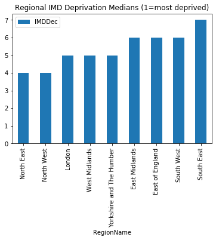

```python
Region = PopDepLSOA.groupby('RegionName').median()

# plot the overall Deprivation index by Region to see the picture for all of England
ax1 = Region[['IMDDec']].sort_values(by ='IMDDec',ascending=True).plot.bar( rot=90)
ax1.set_title('Regional IMD Deprivation Medians (1=most deprived)')
```

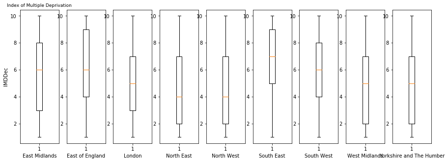

```python
fig,axes = plt.subplots(1,9,figsize=(15,5)) # create Figure fig with subplots axes[0,0] to [1,2]

Regions=PopDepLSOA.groupby(['RegionName']).RegionName.count().index
row=0;col=0
for i in range(len(Regions)):
    axes[i].boxplot(PopDepLSOA['IMDDec'][PopDepLSOA['RegionName']==Regions[i]])
    axes[i].set_xlabel(Regions[i])


axes[0].set_ylabel('IMDDec')
axes[0].set_title('Index of Multiple Deprivation', fontsize=9)

plt.show()
```

These analyses show that the North East and North West of England are the most deprived areas (based on the calculated mean AND the median and lower quartiles shown in the boxplots).

The least deprived area is the South East of England; with a relatively narrow range of deprivation within the quartiles. There is wide variation within regions, all have areas that are classed as the most deprived (decile=1) and the least (decile=10).

### 2.2 Deprivation by Local Authority District

Group the Deprivation data by Local Authority District and show the most deprived districts by the summary IMD.

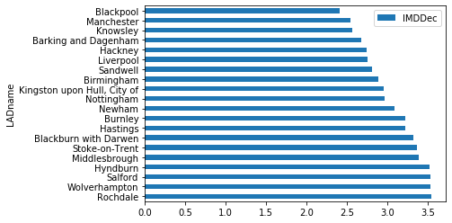

|  | LSOAcode | LSOAname | LADcode | LADname | IMDRank | IMDDec | IncRank | IncDec | EmpRank | EmpDec | ... | OlderPop | WorkingPop | DepChildnPerc | OlderPerc | 16_59Perc | WorkingPerc | RegionCode | RegionName | CountryCode | CountryName |
| --- | --- | --- | --- | --- | --- | --- | --- | --- | --- | --- | --- | --- | --- | --- | --- | --- | --- | --- | --- | --- | --- |
| 21400 | E01021988 | Tendring 018A | E07000076 | Tendring | 1 | 1 | 4 | 1 | 1 | 1 | ... | 685 | 1055.75 | 0.145641 | 0.351282 | 0.503077 | 0.541410 | E12000006 | East of England | E92000001 | England |
| 12280 | E01012673 | Blackpool 010A | E06000009 | Blackpool | 2 | 1 | 1 | 1 | 7 | 1 | ... | 221 | 785.00 | 0.201741 | 0.174842 | 0.623418 | 0.621044 | E12000002 | North West | E92000001 | England |
| 12288 | E01012681 | Blackpool 006A | E06000009 | Blackpool | 3 | 1 | 39 | 1 | 6 | 1 | ... | 304 | 1135.50 | 0.090668 | 0.201191 | 0.708140 | 0.751489 | E12000002 | North West | E92000001 | England |
| 12279 | E01012672 | Blackpool 013B | E06000009 | Blackpool | 4 | 1 | 84 | 1 | 39 | 1 | ... | 268 | 855.50 | 0.134223 | 0.210361 | 0.655416 | 0.671507 | E12000002 | North West | E92000001 | England |
| 12278 | E01012671 | Blackpool 013A | E06000009 | Blackpool | 5 | 1 | 93 | 1 | 40 | 1 | ... | 310 | 900.00 | 0.152817 | 0.218310 | 0.628873 | 0.633803 | E12000002 | North West | E92000001 | England |
| 12358 | E01012751 | Blackpool 013D | E06000009 | Blackpool | 6 | 1 | 8 | 1 | 8 | 1 | ... | 363 | 934.50 | 0.103814 | 0.256356 | 0.639831 | 0.659958 | E12000002 | North West | E92000001 | England |
| 12344 | E01012737 | Blackpool 010E | E06000009 | Blackpool | 7 | 1 | 36 | 1 | 22 | 1 | ... | 300 | 943.25 | 0.153793 | 0.206897 | 0.639310 | 0.650517 | E12000002 | North West | E92000001 | England |
| 12277 | E01012670 | Blackpool 011A | E06000009 | Blackpool | 8 | 1 | 10 | 1 | 43 | 1 | ... | 189 | 699.75 | 0.249581 | 0.158291 | 0.592127 | 0.586055 | E12000002 | North West | E92000001 | England |
| 12289 | E01012682 | Blackpool 008D | E06000009 | Blackpool | 9 | 1 | 11 | 1 | 38 | 1 | ... | 311 | 872.25 | 0.191933 | 0.216273 | 0.591794 | 0.606572 | E12000002 | North West | E92000001 | England |
| 6381 | E01006547 | Liverpool 019C | E08000012 | Liverpool | 10 | 1 | 123 | 1 | 86 | 1 | ... | 253 | 952.25 | 0.204109 | 0.167661 | 0.628231 | 0.631047 | E12000002 | North West | E92000001 | England |
| 12290 | E01012683 | Blackpool 006B | E06000009 | Blackpool | 11 | 1 | 17 | 1 | 11 | 1 | ... | 244 | 901.25 | 0.174891 | 0.177068 | 0.648041 | 0.654028 | E12000002 | North West | E92000001 | England |
| 12281 | E01012674 | Blackpool 013C | E06000009 | Blackpool | 12 | 1 | 112 | 1 | 70 | 1 | ... | 276 | 1000.50 | 0.205901 | 0.173258 | 0.620841 | 0.628060 | E12000002 | North West | E92000001 | England |
| 6391 | E01006558 | Liverpool 018B | E08000012 | Liverpool | 13 | 1 | 109 | 1 | 36 | 1 | ... | 238 | 723.50 | 0.160211 | 0.209507 | 0.630282 | 0.636884 | E12000002 | North West | E92000001 | England |
| 21436 | E01022025 | Tendring 016B | E07000076 | Tendring | 14 | 1 | 108 | 1 | 3 | 1 | ... | 608 | 1029.25 | 0.119246 | 0.337216 | 0.543539 | 0.570854 | E12000006 | East of England | E92000001 | England |
| 24198 | E01024858 | Burnley 007C | E07000117 | Burnley | 15 | 1 | 78 | 1 | 129 | 1 | ... | 200 | 826.75 | 0.254745 | 0.145985 | 0.599270 | 0.603467 | E12000002 | North West | E92000001 | England |
| 12286 | E01012679 | Blackpool 008B | E06000009 | Blackpool | 16 | 1 | 56 | 1 | 169 | 1 | ... | 231 | 873.50 | 0.261842 | 0.151974 | 0.586184 | 0.574671 | E12000002 | North West | E92000001 | England |
| 24248 | E01024908 | Burnley 010E | E07000117 | Burnley | 17 | 1 | 168 | 1 | 334 | 1 | ... | 207 | 755.00 | 0.184391 | 0.177530 | 0.638079 | 0.647513 | E12000002 | North West | E92000001 | England |
| 6440 | E01006611 | Liverpool 012A | E08000012 | Liverpool | 18 | 1 | 29 | 1 | 74 | 1 | ... | 214 | 835.25 | 0.180960 | 0.168371 | 0.650669 | 0.657160 | E12000002 | North West | E92000001 | England |
| 6931 | E01007122 | Wirral 011C | E08000015 | Wirral | 19 | 1 | 7 | 1 | 25 | 1 | ... | 262 | 778.75 | 0.247653 | 0.189170 | 0.563177 | 0.562274 | E12000002 | North West | E92000001 | England |
| 12282 | E01012675 | Blackpool 010B | E06000009 | Blackpool | 20 | 1 | 27 | 1 | 118 | 1 | ... | 242 | 934.75 | 0.241602 | 0.156331 | 0.602067 | 0.603844 | E12000002 | North West | E92000001 | England |

20 rows × 33 columns

```python
#DeprvLADName = PopDepLSOA[['RegionName','LADname','IMDDec']].groupby(['RegionName','LADname']).mean().sort_values(by ='IMDDec',ascending=True)
DeprvLADName = PopDepLSOA[['LADname','IMDDec']].groupby(['LADname']).mean().sort_values(by ='IMDDec',ascending=True)

ax1.set_title('Most Deprived LA Districts (1=most deprived)')
ax1 = DeprvLADName.head(20).sort_values(by ='IMDDec',ascending=False).plot.barh()#( rot=90)
plt.show()

PopDepLSOA.sort_values(by ='IMDRank',ascending=True).head(20)  # show the most deprived LSOAs to cross check results
```

As a result of correlation analysis (further down the doc), showing that Housing and Environment are not correlated with IMD, show the 20 most deprived LA districts for IMD, Housing and Environment Deciles.

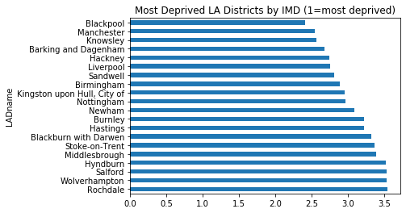

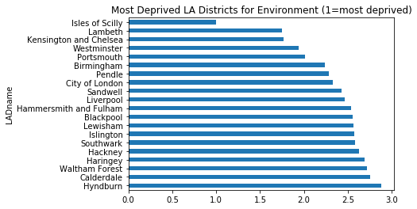

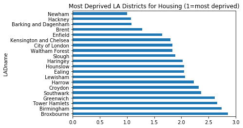

```python
PopDepLSOA.sort_values(by ='IMDRank',ascending=True).head(20)  # show the most deprived LSOAs to check results

DeprvLADName = PopDepLSOA.groupby(['LADname']).mean().sort_values(by ='IMDDec',ascending=True)

ax1 =DeprvLADName['IMDDec'].sort_values(ascending=False).tail(20).plot.barh()#( rot=90)
ax1.set_title('Most Deprived LA Districts by IMD (1=most deprived)')
plt.show()
ax2 = DeprvLADName['EnvDec'].sort_values(ascending=False).tail(20).plot.barh()#( rot=90)
ax2.set_title('Most Deprived LA Districts for Environment (1=most deprived)')
plt.show()
ax3 = DeprvLADName['HouseDec'].sort_values(ascending=False).tail(20).plot.barh()#( rot=90)
ax3.set_title('Most Deprived LA Districts for Housing (1=most deprived)')
plt.show()
```

and show the different rankings side by side in a table to compare.

```python
temp = DeprvLADName['IMDDec'].sort_values(ascending=True)
LADrankIMD=temp.reset_index()
temp = DeprvLADName['HouseDec'].sort_values(ascending=True)
LADrankHouse=temp.reset_index()
temp = DeprvLADName['EnvDec'].sort_values(ascending=True)
LADrankEnv=temp.reset_index()

LADrankIMD['indexIMD'] = LADrankIMD.index
LADrankHouse['indexHouse'] = LADrankHouse.index
LADrankEnv['indexEnv'] = LADrankEnv.index

temp = pd.merge(LADrankIMD,LADrankHouse,left_on=['LADname'], right_on=['LADname'], how='inner')
temp = pd.merge(temp,LADrankEnv,left_on=['LADname'], right_on=['LADname'], how='inner')
temp[['LADname','IMDDec','HouseDec','EnvDec']].sort_values(by='IMDDec',ascending=True).head(20)
#
```

|  | LADname | IMDDec | HouseDec | EnvDec |
| --- | --- | --- | --- | --- |
| 0 | Blackpool | 2.414894 | 8.436170 | 2.553191 |
| 1 | Manchester | 2.542553 | 3.943262 | 3.528369 |
| 2 | Knowsley | 2.561224 | 6.326531 | 3.795918 |
| 3 | Barking and Dagenham | 2.681818 | 1.081818 | 3.500000 |
| 4 | Hackney | 2.743056 | 1.069444 | 2.625000 |
| 5 | Liverpool | 2.751678 | 7.506711 | 2.466443 |
| 6 | Sandwell | 2.811828 | 5.446237 | 2.430108 |
| 7 | Birmingham | 2.890454 | 2.743349 | 2.239437 |
| 8 | Kingston upon Hull, City of | 2.951807 | 5.457831 | 3.228916 |
| 9 | Nottingham | 2.961538 | 4.774725 | 3.670330 |
| 10 | Newham | 3.091463 | 1.000000 | 3.097561 |
| 11 | Burnley | 3.216667 | 8.600000 | 3.416667 |
| 12 | Hastings | 3.226415 | 3.509434 | 5.188679 |
| 13 | Blackburn with Darwen | 3.318681 | 8.263736 | 3.879121 |
| 14 | Stoke-on-Trent | 3.371069 | 7.257862 | 5.062893 |
| 15 | Middlesbrough | 3.383721 | 7.651163 | 7.441860 |
| 16 | Hyndburn | 3.519231 | 9.250000 | 2.884615 |
| 17 | Salford | 3.533333 | 6.206667 | 4.746667 |
| 18 | Wolverhampton | 3.537975 | 5.569620 | 4.170886 |
| 19 | Rochdale | 3.544776 | 6.395522 | 5.828358 |

### 2.3 Population Data

Show some overview stats of Population data to add to understanding and see whether they need to be considered in the overall analysis.

```python
PopRegion = PopDepLSOA[['RegionName','TotalPop']].groupby(['RegionName']).sum().sort_values(by ='TotalPop',ascending=False)

print(PopRegion)
PopRegion.sum() #54728204
```

```
                          TotalPop
RegionName
South East                 8940404
London                     8662622
North West                 7166543
East of England            6068635
West Midlands              5747778
South West                 5467722
Yorkshire and The Humber   5383626
East Midlands              4670229
North East                 2620645
```

```
TotalPop    54728204
dtype: int64
```

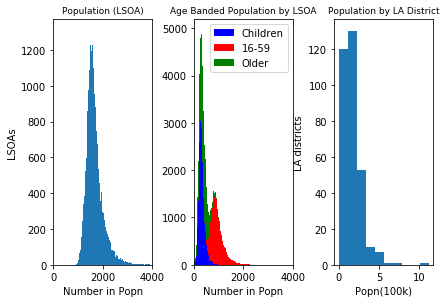

```python
fig,axes = plt.subplots(1,3) # create Figure fig with subplots axes[0,0] to [1,2]
fig.tight_layout()

axes[0].hist(Popn['TotalPop'], bins='auto')
axes[0].set_xlabel('Number in Popn')
axes[0].set_ylabel('LSOAs')
axes[0].set_title('Population (LSOA)', fontsize=9)
axes[0].set_xlim(xmin=0, xmax = 4000)

colors = ['blue', 'red', 'green']
names = ['Children','16-59','Older']

axes[1].hist([Popn['DepChildnPop'], Popn['16_59Pop'], Popn['OlderPop']], bins='auto', stacked=True,
         color = colors , label=names) #
axes[1].set_xlabel('Number in Popn')
axes[1].set_title('Age Banded Population by LSOA', fontsize=9)
axes[1].set_xlim(xmin=0, xmax = 4000)
axes[1].legend()


axes[2].hist(PopDepLAD['TotalPop']/100000, bins=10)
axes[2].set_xlabel('Popn(100k)')
axes[2].set_ylabel('LA districts')
axes[2].set_title('Population by LA District', fontsize=9)
#axes[2].set_xlim(xmin=0, xmax = 4000)

plt.show()
```

### 2.4 Deprivation Spatial Analysis

Visualise the deprivation on a map of the LA districts.

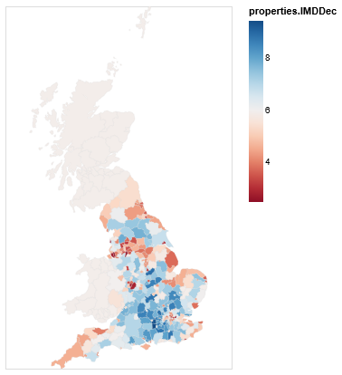

```python
#Index of multiple Deprivation
data_geo = alt.InlineData(values = PopDepMap.to_json(), #geopandas to geojson string
                       format = alt.DataFormat(property='features',type='json'))

alt.Chart(alt.InlineData(values = PopDepMap.to_json(),
                       format = alt.DataFormat(property='features',type='json')) ).mark_geoshape(strokeWidth=1,stroke='lightgray',strokeOpacity=0.2
).encode(color=alt.Color(alt.repeat('column'), type='quantitative', scale=alt.Scale(scheme='redblue')),
    tooltip=['properties.LADname:N',alt.Tooltip(alt.repeat("column"), type="quantitative")]
).properties(
    projection={'type': 'identity','reflectY': True},
    width=250,
    height=400
).repeat(column=['properties.IMDDec'])
```

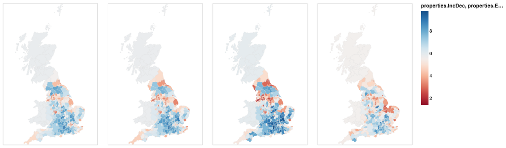

```python
# multiple maps for comparisons

data_geo = alt.InlineData(values = PopDepMap.to_json(), #geopandas to geojson string
                       format = alt.DataFormat(property='features',type='json'))

alt.Chart(alt.InlineData(values = PopDepMap.to_json(),
                       format = alt.DataFormat(property='features',type='json')) ).mark_geoshape(strokeWidth=1,stroke='lightgray',strokeOpacity=0.2
).encode(color=alt.Color(alt.repeat('column'), type='quantitative', scale=alt.Scale(scheme='redblue')),
    tooltip=['properties.LADname:N',alt.Tooltip(alt.repeat("column"), type="quantitative")]
).properties(
    projection={'type': 'identity','reflectY': True},
    width=200,
    height=300
).repeat(column=['properties.IncDec','properties.EmpDec','properties.HealthDec','properties.EduDec'])
```

The maps above show that these areas of Deprivation are concentrated in the North of England, inner cities and some coastal areas.

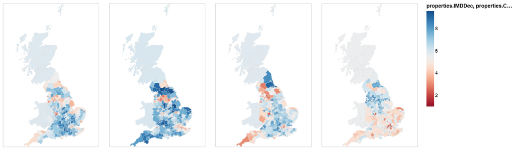

```python
# multiple maps for comparisons

data_geo = alt.InlineData(values = PopDepMap.to_json(), #geopandas to geojson string
                       format = alt.DataFormat(property='features',type='json'))

alt.Chart(alt.InlineData(values = PopDepMap.to_json(),
                       format = alt.DataFormat(property='features',type='json')) ).mark_geoshape(strokeWidth=1,stroke='lightgray',strokeOpacity=0.2
).encode(color=alt.Color(alt.repeat('column'), type='quantitative', scale=alt.Scale(scheme='redblue')),
    tooltip=['properties.LADname:N',alt.Tooltip(alt.repeat("column"), type="quantitative")]
).properties(
    projection={'type': 'identity','reflectY': True},
    width=200,
    height=300
).repeat(column=['properties.IMDDec','properties.CrimeDec','properties.EnvDec','properties.HouseDec'])
```

The maps above show that these deprivation types show very different spatial distribution to the others and between themselves.  
Crime is more specifically clustered in the inner cities.  
Housing Deprivation is almost a mirror image of the overall deprivation picture, ie. worst across the South of England and least in the North - no doubt a factor of higher housing costs in the areas that are overall less deprived.  
Environmental deprivation is specific to inner cities and some less populated areas - this is likely an effect of the factors making up Environmental deprivation - distance to facilities for less populated areas and pollution for inner cities.

## 3 Relationship between the Domains

One of our analytical questions is to look at the relationship between individual Deprivation domains so now we analyse correlation between them.

### 3.1 Correlation between IMD and the other domains (by LAD)

Visualise IMD correlation to each of the other domains:

```python
#function to show multi scatter plots for any array and set of attributes
def MultiScatter(array,main,columns,cols,rows):
    fig,axes = plt.subplots(rows,cols,figsize=(20,10),constrained_layout=True) #,constrained_layout=True# figsize=(10, 10)create Figure fig with subplots axes[0,0] to [1,2]

    row=0;col=0
    for i in range(columns): #len(student.columns)
        if temp.columns[i] != main:
            axes[row,col].set(xlabel=temp.columns[i],ylabel=main)
            axes[row,col].scatter(temp[temp.columns[i]],temp[main],alpha=0.4,c='blue')
            col=col+1
        if col >= cols:
            col=0
            row=row+1
            if row >= rows:
                exit
    plt.show()
    # add this for different colours:   colors=array['RegionName'], c=colors set colours to regions
```

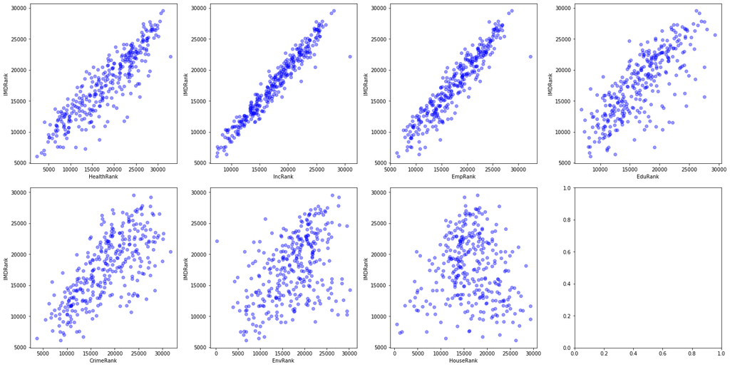

```python
temp=PopDepLAD[['IMDRank','HealthRank','IncRank','EmpRank','EduRank','CrimeRank','EnvRank','HouseRank']]
MultiScatter(temp,'IMDRank',8,4,2)
```

### 3.2 Correlation between all variables

Calculate the correlation coefficients between all features in the LSOA dataset and show on a Heatmap.

```python
# exclude the deciles, as they were features engineered from the ranks so not relevant

#NoDeciles = [col for col in PopDepLSOA.columns if 'Dec' not in col]
ColumnList = ['DepChildnPerc',    'OlderPerc', '16_59Perc', 'WorkingPerc',
              'IMDRank', 'IncRank',    'EmpRank', 'EduRank',  'HealthRank',  'CrimeRank', 'HouseRank', 'EnvRank']

# create a correlation matrix excluding the decile columns & absolute population values
correlation = PopDepLSOA[ColumnList].corr(method='pearson') # try switching to another type??

corr_matrix = pd.melt(correlation.reset_index(),id_vars=['index'])
corr_matrix = corr_matrix.rename(columns={'index': 'var1','variable': 'var2'})

corr_matrix.var1.count()
corr_matrix.head()
```

|  | var1 | var2 | value |
| --- | --- | --- | --- |
| 0 | DepChildnPerc | DepChildnPerc | 1.000000 |
| 1 | OlderPerc | DepChildnPerc | -0.550000 |
| 2 | 16_59Perc | DepChildnPerc | 0.040494 |
| 3 | WorkingPerc | DepChildnPerc | -0.045242 |
| 4 | IMDRank | DepChildnPerc | -0.345864 |

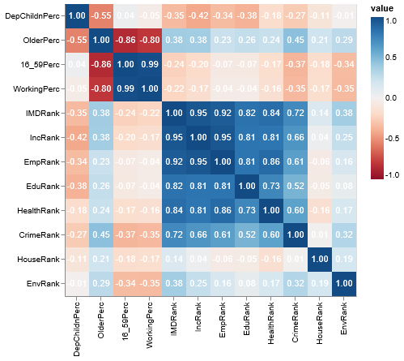

```python
# create a heatmap showing the correlation values between pairs of attributes

base = alt.Chart(corr_matrix).encode(
    x=alt.X('var1:N',scale=alt.Scale(paddingInner=0),sort=alt.EncodingSortField('index', order='ascending')),
    y=alt.Y('var2:N',scale=alt.Scale(paddingInner=0),sort=alt.EncodingSortField('index', order='ascending')),
)

heatmap = base.mark_rect().encode(
    color=alt.Color('value:Q', scale=alt.Scale(domain=[-1,1],scheme='redblue')),
    tooltip=['value','var1','var2']
    )

text = base.mark_text(baseline='middle').encode(
    alt.Text('value',format='.2f'),
    color=alt.value('white'),
    tooltip=['value','var1','var2']
)

(heatmap + text).properties(width=360,height=360).configure_axis(title=None)
#corr_matrix.head()
```

### 3.2 Heatmap Findings

see report.

### 3.3 Most Correlated Pairs

Show the most significant pairwise correlations ordered in a table excluding: attribute correlated to itself, rows correlated to IMDRank (engineered from domains) and population correlations.

This shows that Employment, Income, Health and Education are all more strongly correlated to each other than to any other domains.

```python
# r or summmary IMD (engineered from domains) or the Popn %s
corr_reduce = corr_matrix.drop(corr_matrix[corr_matrix['var1']==corr_matrix['var2']].index)
corr_reduce = corr_reduce.drop(corr_reduce[corr_reduce['var1']=='IMDRank'].index)
corr_reduce = corr_reduce.drop(corr_reduce[corr_reduce['var2']=='IMDRank'].index)
corr_reduce = corr_reduce.drop(corr_reduce[(corr_reduce['var2'].str.contains('Perc') & corr_reduce['var1'].str.contains('Perc'))].index)
#corr_reduce = corr_reduce.drop(corr_reduce[corr_reduce['var2'].str.contains('Perc')].index)
#corr_reduce = corr_reduce.drop(corr_reduce[corr_reduce['var1'].str.contains('Perc')].index)

# Add a column with the absolute correlation and sort on it

corr_reduce['abs_corr']=abs(corr_reduce['value'])
corr_reduce=corr_reduce.sort_values(by ='abs_corr',ascending=False)

print()
print("Top 20 most correlated pairs of variables")
print(corr_reduce.head(30))

corr_reduce.head()
```

```
Top 20 most correlated pairs of variables
              var1           var2     value  abs_corr
77         IncRank        EmpRank  0.948254  0.948254
66         EmpRank        IncRank  0.948254  0.948254
80      HealthRank        EmpRank  0.857962  0.857962
102        EmpRank     HealthRank  0.857962  0.857962
89         IncRank        EduRank  0.814300  0.814300
67         EduRank        IncRank  0.814300  0.814300
79         EduRank        EmpRank  0.813861  0.813861
90         EmpRank        EduRank  0.813861  0.813861
68      HealthRank        IncRank  0.809246  0.809246
101        IncRank     HealthRank  0.809246  0.809246
92      HealthRank        EduRank  0.731170  0.731170
103        EduRank     HealthRank  0.731170  0.731170
69       CrimeRank        IncRank  0.659529  0.659529
```

[output cut: 17 more lines]

|  | var1 | var2 | value | abs_corr |
| --- | --- | --- | --- | --- |
| 77 | IncRank | EmpRank | 0.948254 | 0.948254 |
| 66 | EmpRank | IncRank | 0.948254 | 0.948254 |
| 80 | HealthRank | EmpRank | 0.857962 | 0.857962 |
| 102 | EmpRank | HealthRank | 0.857962 | 0.857962 |
| 89 | IncRank | EduRank | 0.814300 | 0.814300 |

### 3.4 Correlation - by Region

Now that we know the domains that are most closely correlated, drill down to see if this is still the case for individual regions.  
Show the individual domains by Region - splitting the visualisations by attribute correlation.

1. Income, Employment and, Health
2. Education, Crime, Housing and Environment

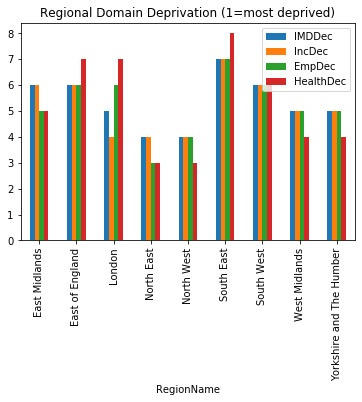

```python
# another way of showing the correlation of Inc/Emp dec found in the correlation analysis
ax2 = Region[['IMDDec','IncDec','EmpDec','HealthDec']].plot.bar( rot=90)
ax2.set_title('Regional Domain Deprivation (1=most deprived)')
```

see report for a discussion of the disparities.

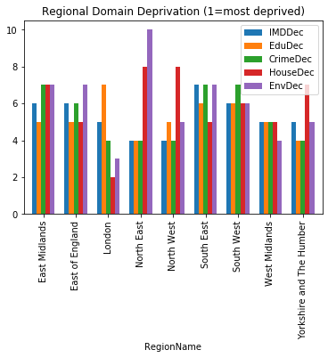

```python
ax3 = Region[['IMDDec','EduDec','CrimeDec','HouseDec','EnvDec']].plot.bar(width=0.7, rot=90)
ax3.set_title('Regional Domain Deprivation (1=most deprived)')
```

see report for a discussion of the disparities.

### 3.4 Correlation Analysis by Region

Redo Correlation Analysis for EACH of the Regions where a disparity was found above.

```python
# Create the correlation matrix again for REgion subsets

NoDeciles = [col for col in PopDepLSOA.columns if 'Dec' not in col]
ColumnList = ['DepChildnPerc',    'OlderPerc', '16_59Perc', 'WorkingPerc',
              'IMDRank', 'IncRank',
       'EmpRank', 'EduRank',  'HealthRank',
       'CrimeRank', 'HouseRank', 'EnvRank']

# create a correlation matrix excluding the decile columns & absolute population values
#temp = PopDepLSOA[ColumnList][PopDepLSOA['RegionName']=='London'].corr(method='pearson')
#temp = PopDepLSOA[ColumnList][PopDepLSOA['RegionName']!='London'].corr(method='pearson')
#temp = PopDepLSOA[ColumnList][PopDepLSOA['RegionName']=='North West'].corr(method='pearson')
temp = PopDepLSOA[ColumnList][PopDepLSOA['RegionName']=='North East'].corr(method='pearson')

corr_region = pd.melt(temp.reset_index(),id_vars=['index'])
corr_region=corr_region.rename(columns={'index': 'var1','variable': 'var2'})
corr_region.head()
```

|  | var1 | var2 | value |
| --- | --- | --- | --- |
| 0 | DepChildnPerc | DepChildnPerc | 1.000000 |
| 1 | OlderPerc | DepChildnPerc | -0.501298 |
| 2 | 16_59Perc | DepChildnPerc | -0.073154 |
| 3 | WorkingPerc | DepChildnPerc | -0.165544 |
| 4 | IMDRank | DepChildnPerc | -0.429977 |

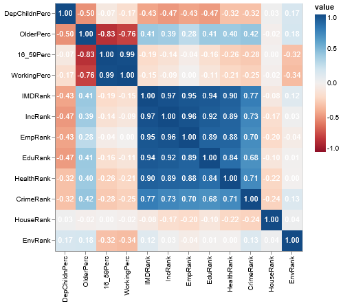

```python
base = alt.Chart(corr_region).encode(
    x=alt.X('var1:N',scale=alt.Scale(paddingInner=0),sort=alt.EncodingSortField('index', order='ascending')),
    y=alt.Y('var2:N',scale=alt.Scale(paddingInner=0),sort=alt.EncodingSortField('index', order='ascending')),
)

heatmap = base.mark_rect().encode(
    color=alt.Color('value:Q', scale=alt.Scale(domain=[-1,1],scheme='redblue')),
    tooltip=['value','var1','var2']
    )

text = base.mark_text(baseline='middle').encode(
    alt.Text('value',format='.2f'),
    color=alt.value('white'),
    tooltip=['value','var1','var2']
)

(heatmap + text).properties(width=360,height=360).configure_axis(title=None)
#corr_region.head()
```

Subsets of the regions and individual regions still show similar strong/weak correlation values for the same domain pairs so we can still model the Health predictors as Linear Regressions but each subset may need an individual model for most accurate prediction.

## 4. linear regression models

We will now try to model the Health deprivation as a linear regression to analyse how well it can be predicted from other domains.

### 4.1 Health Correlation to other domains

```python
#  Analyse Health correlation
print("Top ten most correlated pairs of variables with 'HealthRank'")
corr_health=correlation[['HealthRank']]
corr_health=corr_health.sort_values(by ='HealthRank',ascending=False)
print(corr_health) # show the single col correlation matrix
```

```
Top ten most correlated pairs of variables with 'HealthRank'
               HealthRank
HealthRank       1.000000
EmpRank          0.857962
IMDRank          0.844306
IncRank          0.809246
EduRank          0.731170
CrimeRank        0.598931
OlderPerc        0.237603
EnvRank          0.169644
HouseRank       -0.158532
WorkingPerc     -0.158672
16_59Perc       -0.170798
DepChildnPerc   -0.183746
```

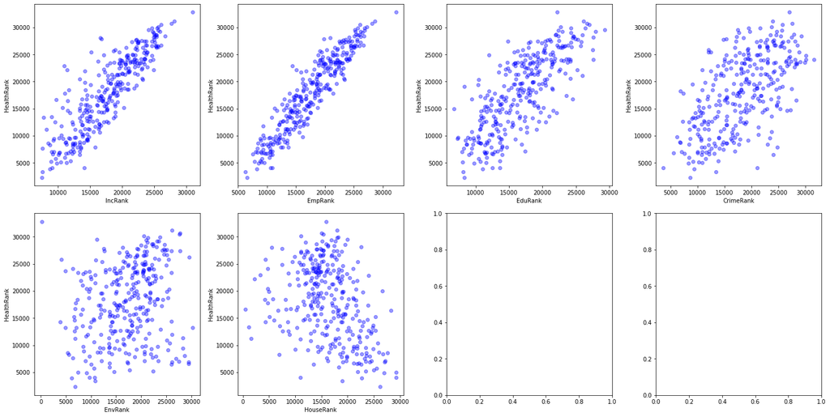

```python
temp=PopDepLAD[['HealthRank','IncRank','EmpRank','EduRank','CrimeRank','EnvRank','HouseRank']]
MultiScatter(temp,'HealthRank',7,4,2)
```

Health is most strongly correlated with Employment and Income. As we saw earlier, Income and Employment are very highly correlated with each other so we will model Health as a Linear Regression from Employment.

```python
# compare the Pearson and Spearman correlations for Health/Employment
# they are almost identical so either could be used

import scipy.stats as stats

column1=PopDepLSOA["HealthRank"];
column2=PopDepLSOA["EmpRank"];

corrPearson, pValPearson = stats.pearsonr(column1,column2)
print ("Pearson's correlation is", corrPearson, "with a p-value of",pValPearson)

corrSpearman, pValSpearman = stats.spearmanr(column1,column2)
print ("Spearman's correlation is", corrSpearman, "with a p-value of",pValSpearman)
```

```
Pearson's correlation is 0.8579618172568885 with a p-value of 0.0
Spearman's correlation is 0.8579618318847234 with a p-value of 0.0
```

```python
def RegressScatter (pd,colname1,colname2):
# a function to plot a regression line and scatter plot from any 2 columns of a given matrix
    column1=pd[colname1];
    column2=pd[colname2];

    slope, intercept, r_value, p_value, std_err = stats.linregress(column1, column2)

    print ("Slope: ", slope)
    print ("Intercept: ", intercept)
    print ("r_value: ", r_value)
    print ("p_value: ", p_value)
    print ("std_err: ", std_err)

    #Calculate 2 points directly from the parameters
    x1=column1.min()
    x2=column1.max()
    y1=x1*slope + intercept
    y2=x2*slope + intercept

    #Plot a scatterplot
    plt.suptitle(colname1 + ' vs. ' + colname2)
    plt.xlabel(colname1)
    plt.ylabel(colname2)
    plt.scatter(column1,column2 , c = "red", s = 30, alpha = 0.2, linewidth='0')

    #overlay the modelled line
    plt.plot([x1,x2],[y1,y2])
```

### 4.2 Health Deprivation Linear Regression

Model Health deprivation as a linear regression, predicted by Employment deprivation.  
This was originally done with the LSOA rank data but the relationship and the outliers are shown more clearly with the less granular LA district figures and the scatter plots offer more clarity using the deciles instead of ranks.  
The results below confirm that Employment provides the best fitted regression, with the highest r-values and lowest p-value.

```
Slope:  1.261468157966843
Intercept:  -1.4147559249631065
r_value:  0.9347616301040529
p_value:  2.563954937582572e-146
std_err:  0.026760127753821288
```

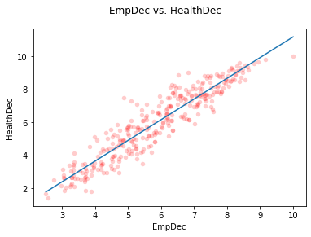

```python
#RegressScatter(PopDepLSOA,'EmpRank','HealthRank')
#RegressScatter(PopDepLAD,'EmpDec','HealthDec')
RegressScatter(PopDepLAD,'EmpDec','HealthDec')
```

This regressions above shows that for every unit decrease in Employment Deprivation ranking, there is a 1.3 decrease in Health Deprivation. P-value is zero (to the accuracy of many decimal places) showing that this relationship is statistically significant.

The scatter plot is also showing that there are some outliers where Health is both more and less deprived than the model would suggest based upon Employment deprivation - these may correspond to the Regions we have identified with Health differences.

```
Slope:  1.2533137247040875
Intercept:  -1.390343711664964
r_value:  0.868739020448761
p_value:  5.667002434650062e-100
std_err:  0.039880454396176074
```

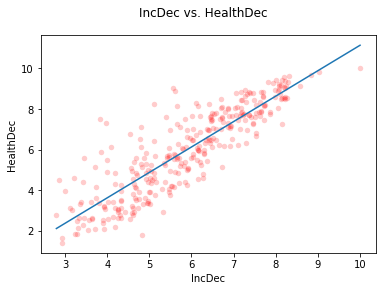

```python
#RegressScatter(PopDepLSOA,'IncRank','HealthRank')
RegressScatter(PopDepLAD,'IncDec','HealthDec')
```

Modelling Health as a function of Income deprivation still gives us a reasonable model but with more errors/outliers than that using Employment.

### 4.3 Health Linear Regression of Regional Subsets

Linear regressions are modelled for the region subsets whose Health/Employment correlations most closely resembled each other.

The model for London alone has many outliers - this is possibly a cause of a wider variability in deprivation there.

```
Slope:  1.1428073392996854
Intercept:  0.11750606619001314
r_value:  0.8632477114543108
p_value:  1.0195455848716447e-10
std_err:  0.12002157953539362
```

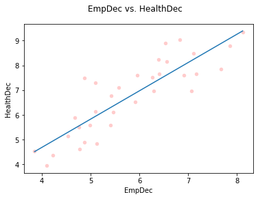

```python
# model with London only
temp = PopDepLAD[PopDepLAD['RegionName'].isin(['London'])]
RegressScatter(temp,'EmpDec','HealthDec')
```

```
Slope:  1.2695227875149235
Intercept:  -1.557755718176292
r_value:  0.947948852326386
p_value:  3.631155177328125e-145
std_err:  0.025128310004074724
```

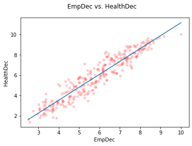

```python
# EXCLUDE London
temp = PopDepLAD[~PopDepLAD['RegionName'].isin(['London'])]
RegressScatter(temp,'EmpDec','HealthDec')
```

```
Slope:  0.7978128029212199
Intercept:  0.04788223449831408
r_value:  0.8185525770720238
p_value:  0.0011322484247738792
std_err:  0.1770487048941803
```

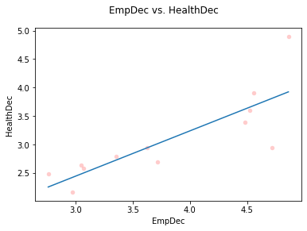

```python
temp = PopDepLAD[PopDepLAD['RegionName'].isin(['North East'])]
RegressScatter(temp,'EmpDec','HealthDec')
```

```
Slope:  1.333119421406903
Intercept:  -1.632992378990199
r_value:  0.9525175452970791
p_value:  2.6154399788691422e-23
std_err:  0.06575601411610534
```

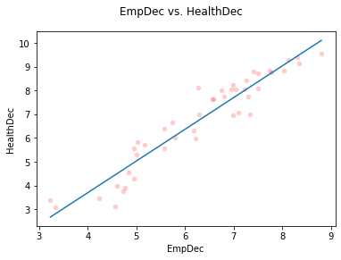

```python
temp = PopDepLAD[PopDepLAD['RegionName'].isin(['East of England'])]
RegressScatter(temp,'EmpDec','HealthDec')
```

```
Slope:  1.271747461437339
Intercept:  -1.499551414138426
r_value:  0.9333174106658166
p_value:  1.8151528198791145e-40
std_err:  0.05245292294881442
```

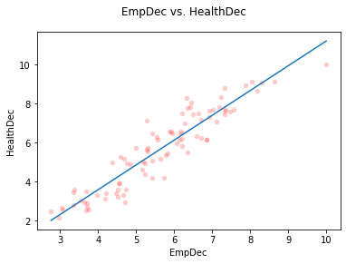

```python
temp = PopDepLAD[PopDepLAD['RegionName'].isin(['South West','East Midlands','North East'])]
RegressScatter(temp,'EmpDec','HealthDec')
```

```
Slope:  1.25302606235884
Intercept:  -1.7212226092301615
r_value:  0.9526444891934744
p_value:  2.836395757863275e-47
std_err:  0.04263681561912054
```

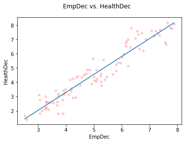

```python
temp = PopDepLAD[PopDepLAD['RegionName'].isin(['North West','West Midlands','Yorkshire and The Humber'])] #
RegressScatter(temp,'EmpDec','HealthDec')
```